# My First R Marckdown Doc

My First markdwon file

I used I used the info [here](https://rpubs.com/sureshbk/358994) and [here](https://rstudio-pubs-static.s3.amazonaws.com/300758_367ce30144b44cd4901bedfa279bb64c.html) to complete the assignment.

# I downloaded the data set, and I set my directory

```r
setwd ("C:/Users/Charlotte/Documents/GitHub/RepData_PeerAssessment1")
```

# Open/load the file

```r
DataFrame <- read.csv( "activity.csv")
```

spent an hr with errors trying to figure out how install packages in Kniter until I figure out on the net U don’t. Why wouldn’t the lectures cover that … Wow? I used 1. install.packages(“dplyr”) 2. install.packages(“ggplot2”) 3. install.packages(“magrittr”) 4. library(tidyverse)

# Calculate the total number of steps taken per day?

Get number of steps per date and sum results removing null

```r
totalstepsperday <- aggregate(steps ~ date, data = DataFrame, FUN = sum, na.rm = TRUE)
```

put date in YYYYMMDD format

```r
DataFrame$date <- as.Date(DataFrame$date, "%Y-%m-%d")
```

Make a histogram of the total number of steps taken each day. convert dates first A "Histograms are used to show distributions of variables while bar charts are used to compare variables. Via [Forbes mag](https://www.forbes.com/sites/naomirobbins/2012/01/04/a-histogram-is-not-a-bar-chart/?sh=27f69e816d77)

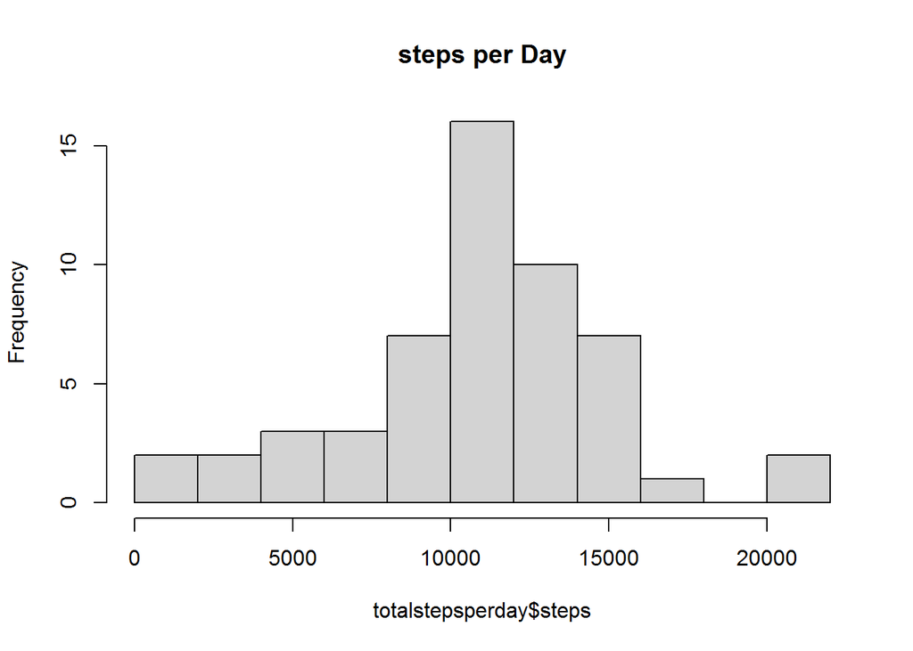

```r
hist(totalstepsperday$steps, main = "steps per Day", breaks = 10)
```

# Calculate and report the mean and median total number of steps taken per day.

calculate the mean:

```r
mean_steps <- mean(totalstepsperday$steps)
mean_steps
```

```
## [1] 10766.19
```

#Calculate median

```r
median_steps <- median(totalstepsperday$steps)
median_steps
```

```
## [1] 10765
```

# NEXT What is the average daily activity pattern?

Make a time series plot (of type 1) the 5-minute interval (x-axis)and the average number of steps taken, averaged across all days (y-axis).

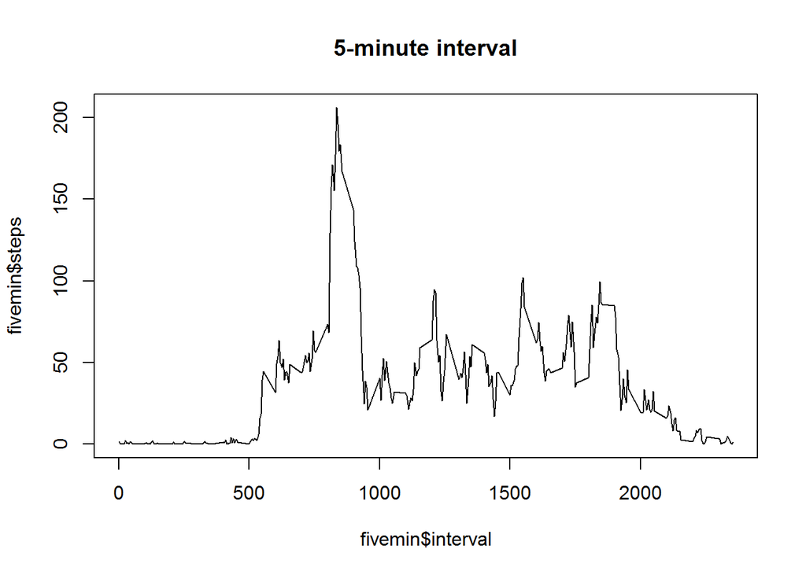

```r
fivemin <- aggregate(steps ~ interval, data = DataFrame, FUN = mean, na.rm = TRUE)
plot (x = fivemin$interval, y = fivemin$steps, type = "l", main = "5-minute interval")
```